# L03 ggplot 2

Data Visualization (STAT 302)

Author

Shuo Han

## Datasets

We will be using the BRFSS survey which was introduced in the last lab. The data was supplied in `cdc.txt` file and should be in your `/data` subdirectory. If not, you need to download the last lab to get this data file. As a reminder, the dataset contains 20,000 complete observations/records of 9 variables/fields, described below.

- `genhlth` - How would you rate your general health? (excellent, very good, good, fair, poor)
- `exerany` - Have you exercised in the past month? (`1 = yes`, `0 = no`)
- `hlthplan` - Do you have some form of health coverage? (`1 = yes`, `0 = no`)
- `smoke100` - Have you smoked at least 100 cigarettes in your life time? (`1 = yes`, `0 = no`)
- `height` - height in inches
- `weight` - weight in pounds
- `wtdesire` - weight desired in pounds
- `age` - in years
- `gender` - `m` for males and `f` for females

```r
# Load package(s)
library(tidyverse)
library(lubridate)

# Load data
cdc_data <- read_delim("data/cdc.txt", delim="|")
```

## Exercise 1

Using the `cdc` dataset, we want to look at the relationship between height and weight. Recreate the following graphics as precisely as possible.

### Plot 1

*Hints:*

- Transparency is 0.2
- Minimal theme

**Solution**

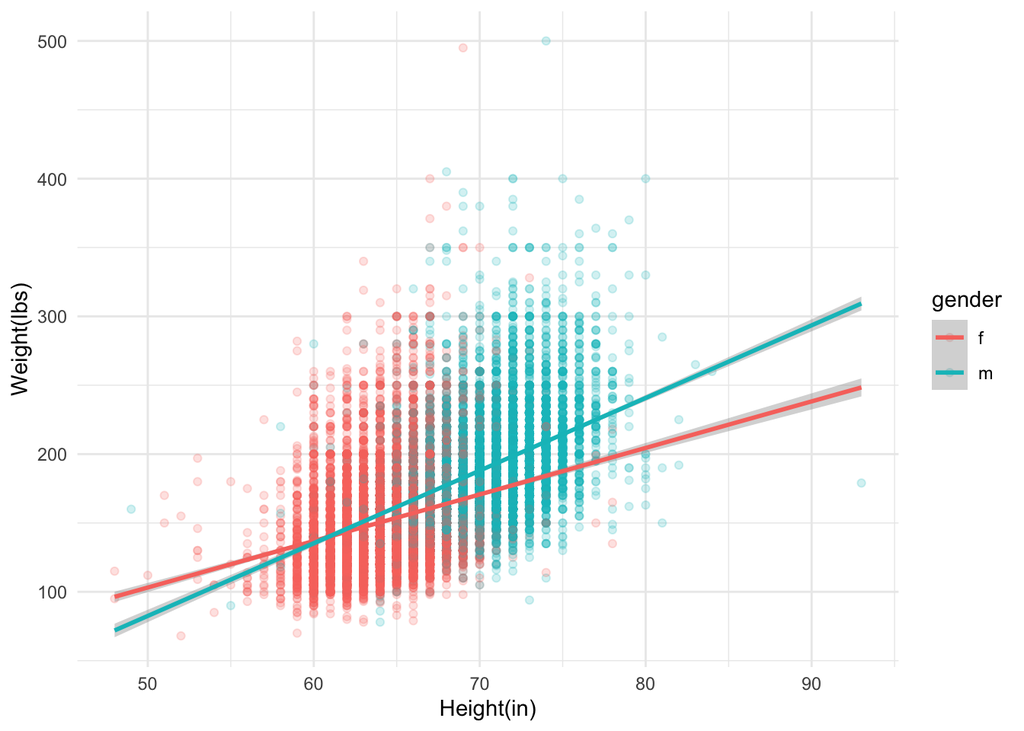

```r
ggplot(cdc_data, aes(height, weight, color = gender)) +
  geom_point(alpha=0.2) +
  geom_smooth(method = lm, fullrange= TRUE) +
  labs(x = "Height(in)", y = "Weight(lbs)") +
  theme_minimal()
```

### Plot 2

*Hints:*

- linewidth = 0.7

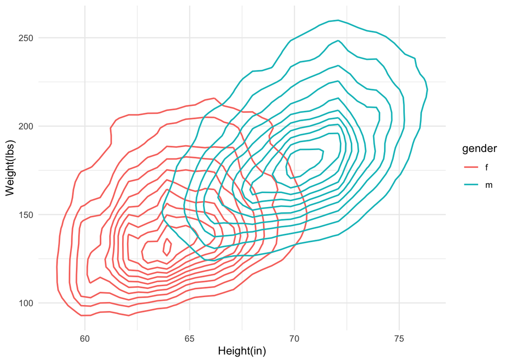

```r
ggplot(cdc_data, aes(height, weight, color = gender)) +
  geom_density_2d(size = 0.7) +
  labs(x = "Height(in)", y = "Weight(lbs)") +
  theme_minimal()
```

### Plot 3

*Hints:*

- `bins` set to 35

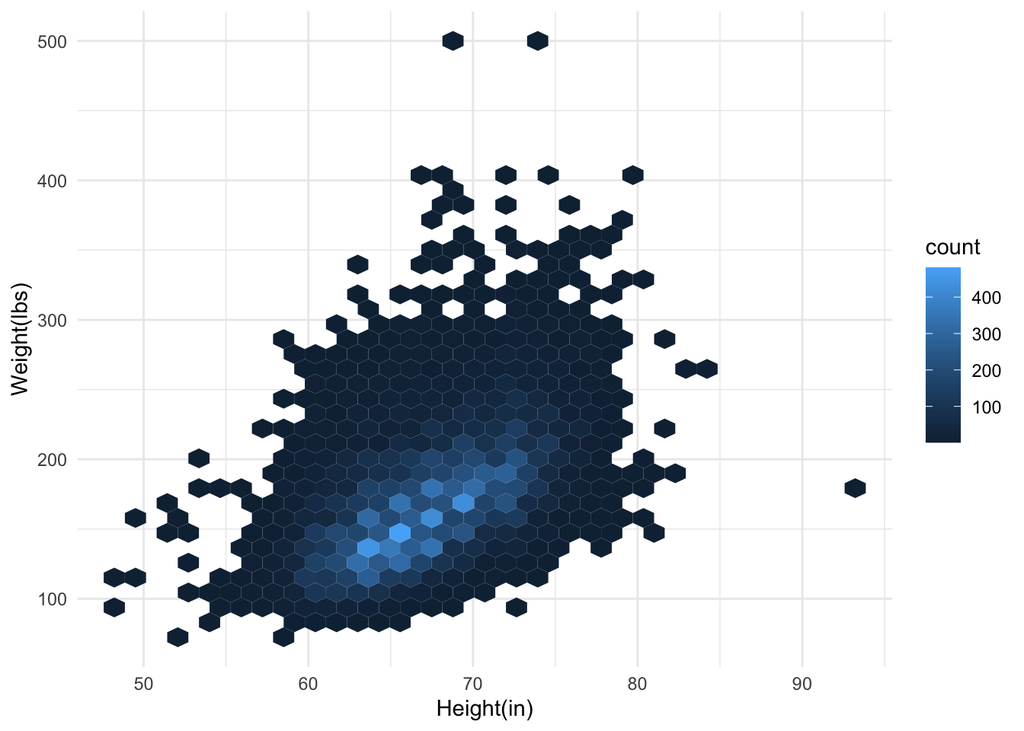

```r
ggplot(cdc_data, aes(height, weight)) +
  geom_hex(bins = 35) +
  labs(x = "Height(in)", y = "Weight(lbs)") +
  theme_minimal()
```

### Plot 4

*Hints:*

- use a stat layer, not a geom layer
- `geom = "polygon"`

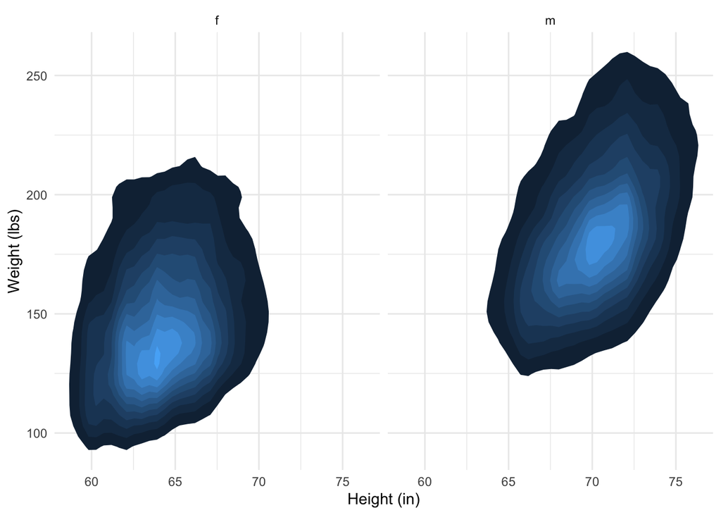

```r
ggplot(cdc_data, aes(height, weight)) +
  stat_density2d(aes(fill = ..level..), geom = "polygon", show.legend = FALSE) +
  facet_wrap(~gender) +
  labs(x = "Height (in)", y = "Weight (lbs)") +
  theme_minimal()
```

## Exercise 2

Using the `cdc_means` dataset derived from the `cdc` dataset, recreate the following graphic as precisely as possible.

*Hints:*

- Hex color code `#56B4E9`
- 95% confidence intervals (1.96 or `qnorm(0.975)`)
- Some useful values: 0.1, 0.7

```r
# data wrangling
# calc mean and se for CI
cdc_means <- cdc_data %>%
  mutate(wtloss = weight - wtdesire) %>%
  group_by(genhlth) %>%
  summarize(
    mean = mean(wtloss),
    se = sd(wtloss) / sqrt(n())
  ) %>%
  mutate(genhlth = fct_reorder(factor(genhlth), desc(mean)))
```

**Solution**

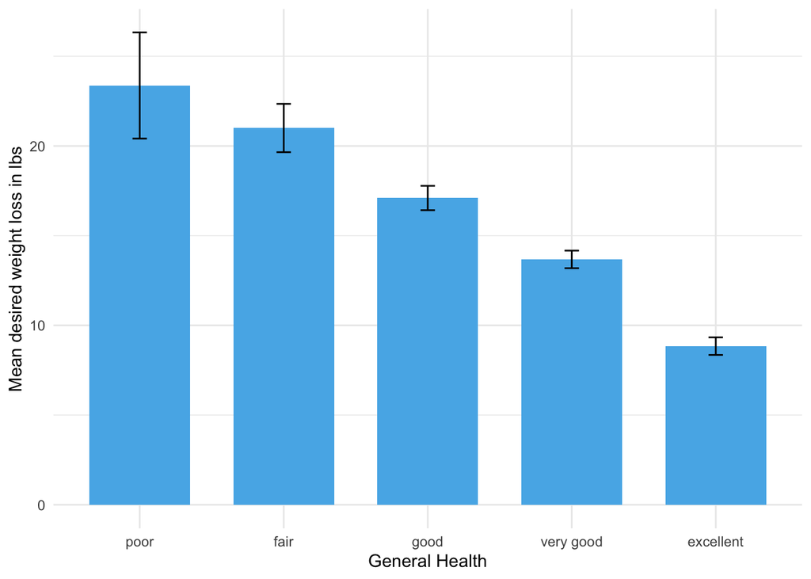

```r
ggplot(cdc_means, aes(genhlth, mean)) +
  geom_col(fill = "#56B4E9", width = 0.7) +
  geom_errorbar(aes(ymin = mean - se*qnorm(0.975), ymax = mean + se*qnorm(0.975)), width = 0.1) +
  labs(x = "General Health", y = "Mean desired weight loss in lbs") +
  theme_minimal()
```

## Exercise 3

Using the `cdc_weight_95ci` dataset derived from the `cdc` dataset, recreate the following graphic as precisely as possible.

*Hints:*

- Useful values: 0.1, 0.5
- Need to know CI formula

```r
# data wrangling
# calculate mean, se, and margin of error for CI formula
cdc_weight_95ci <- cdc_data %>%
  group_by(genhlth, gender) %>%
  summarise(
    mean_wt = mean(weight),
    se = sd(weight) / sqrt(n()),
    moe = qt(0.975, n() - 1) * se
  ) %>%
  ungroup()
```

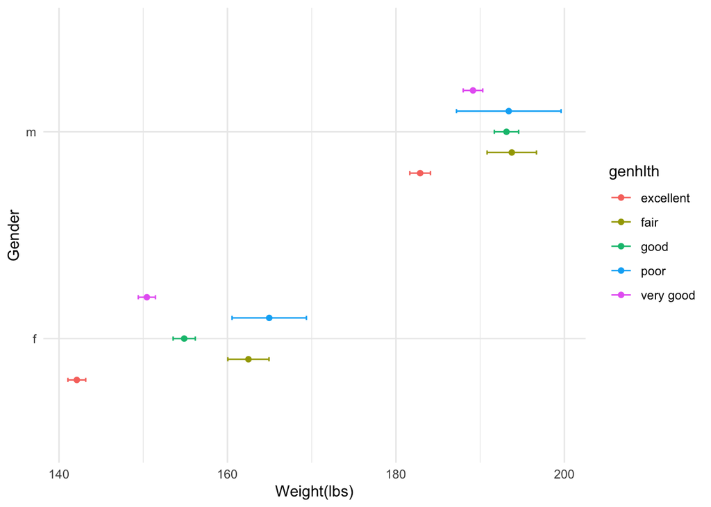

```r
ggplot(cdc_weight_95ci,aes(mean_wt, gender, color = genhlth)) +
  geom_errorbar(aes(xmin = mean_wt - moe, xmax = mean_wt + moe),width = 0.1, position = position_dodge(0.5)) +
  geom_point(position = position_dodge(0.5)) +
  labs(x= "Weight(lbs)", y = "Gender") +
  theme_minimal()
```